# Workflow of the rPACI package

The **rPaci** package is developed to facilitate the calculation and interpretation of several indices for detecting corneal irregularities, and especially keratoconus. These indices were introduced in Ramos-López et al. (2011), Ramos-López et al. (2013) and Castro-Luna, Martínez-Finkelshtein, and Ramos-López (2020), and proved to be effective in detecting keratoconus and early keratoconus.

## Package installation

**rPaci** depends on the **bnlearn** package. To install and load the package and its dependencies, open an R session and write the following code:

```r
install.packages("rPACI", dependencies = T)
library("rPACI")
```

## Reading data

In order to begin with the analysis, the data exported by a typical commercial Placido disk topographer (formatted as described before) can be loaded using the function `readCornealTopography()`. In this example, a sample file with the corneal topography of a normal eye (included in the package as `N01.txt`) is used:

```r
dataset_N = readCornealTopography(system.file("extdata","N01.txt", package="rPACI"))
```

This function returns a `data.frame` conveniently formatted to be used in the next step of the analysis.

## Computing the Placido irregularity indices

We can now compute the Placido irregularity indices of this data set by calling function `computePlacidoIndices()`, which takes the object returned by `readCornealTopography()` as its only argument:

```r
results_N = computePlacidoIndices(dataset_N)
results_N
```

[output not shown]

The object returned by `computePlacidoIndices()` is of class `data.frame` and contains 12 columns and 1 row (because we are analyzing only one eye). The first column of the returned `data.frame` is the diagnosis, based on the GLPI index, which can be either `Irregular cornea` (GLPI $\geq$ 70), `Suspect cornea` (30 $\leq$ GLPI <70) or `Normal cornea` (GLPI <30). The next column is the Naive Bayes Index (NBI), which ranges between 0 and 100 and can be interpreted as the probability of suffering from keratoconus. The remaining columns correspond to the other indices (see definitions in the previous sections).

## Plotting the results

The results of the analysis can be plotted using function `plotSingleCornea()`, which takes 3 arguments: `dataset`, a `data.frame` containing the corneal topography data, i.e., the object returned by `readCornealTopography()`; `PlacidoIndices`, a `data.frame` containing the computed Placido indices, i.e., the object returned by `computePlacidoIndices()`; and, optionally, `filename`, a character vector to be displayed on the plot (for instance, the filename of the corneal topography dataset).

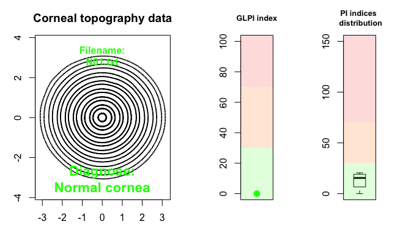

```r
  plotSingleCornea(dataset_N, results_N, filename = "N01.txt")
```

The left-hand side of the figure shows the input data, whereas the right-hand side shows two charts: the GLPI index plot, which visually indicates the value taken by this index on a colored scale of possible values, and the PI indices distribution, which shows the distribution of the GLPI, PI-1, PI-2 and PI-3 indices in a boxplot placed on a scale of possible values. The color of the charts indicate whether the indices fall within the *normal cornea* region (green color), *suspicious cornea* region (orange color), or *irregular cornea* region (red color). In the example shown, we can clearly see that the eye is diagnosed as normal.

## Using the wrapper function

Alternatively to the aforementioned 3 functions, the wrapper function `analyzeFile()` can be used instead, which takes 2 arguments: `path`, which is a character element indicating the location of the corneal topography file, and `drawplot`, which is a logical argument indicating whether the results should be plotted or not. This function returns a `data.frame` containing the same information as the object returned by `computePlacidoIndices()` and, optionally, the plot returned by `plotSingleCornea()` if the argument `drawplot` is `TRUE`.

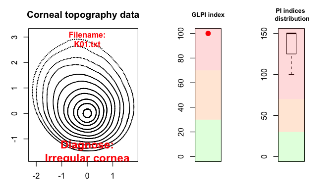

```r
  res_K = analyzeFile(system.file("extdata","K01.txt", package="rPACI"), drawplot=TRUE)
```

```r
res_K
```

```
#>           Diagnose NBI GLPI PI_1 PI_2 PI_3       SL     AR_1     AR_2     AR_3
#> 1 Irregular cornea 100  100  150  150  150 141.8956 118.9002 71.86885 82.74312
#>       AR_4     AR_5
#> 1 73.32595 76.20055
```

## Analizing multiple patients simoultaneously

So far, these functions can only be used to analyze one file at a time. In order to analyze multiple files simultaneously, the function `analyzeFolder()` can be used. This function takes 4 arguments: `path`, to indicate the location of the folder containing the files; `fileExtension`, which indicates the extension of the files, is set to ‘txt’ by default; `individualPlots`, which is an optional logical argument indicating whether the plot for each file should be displayed or not; and `summaryPlot`, which is an optional logical argument indicating whether a summary plot of all files analyzed should be displayed or not. If the argument `summaryPlot()` is `TRUE`, then a barplot showing the absolute frequency of each possible value of diagnosis is depicted.

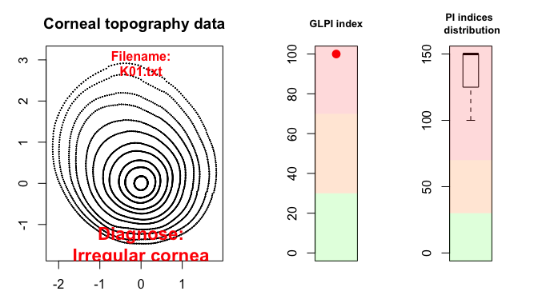

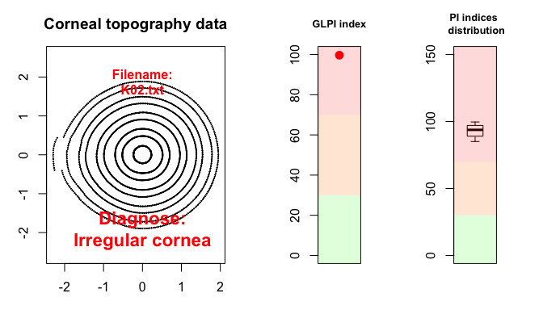

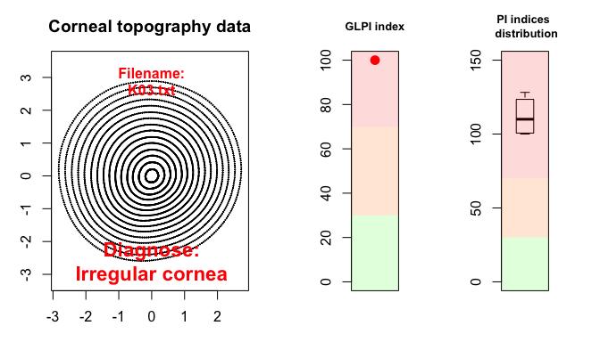

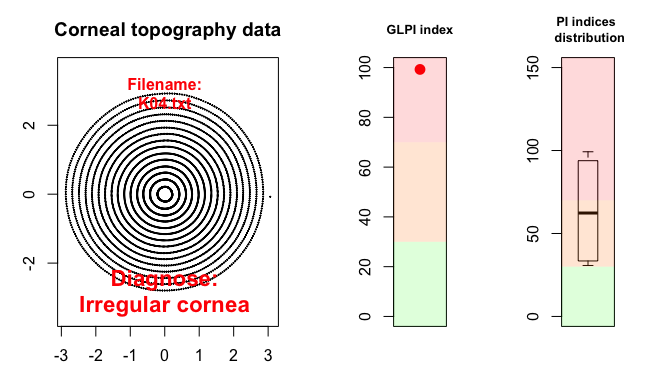

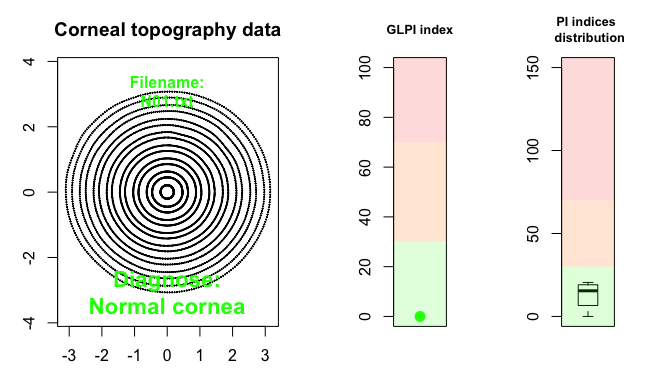

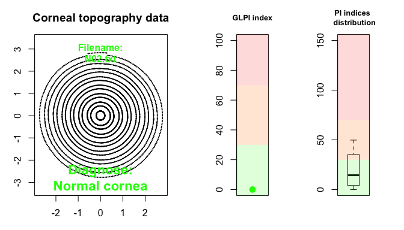

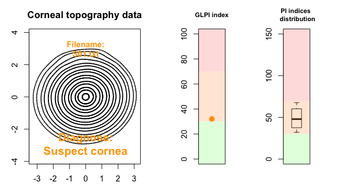

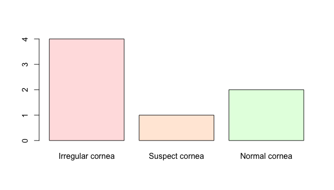

```r
resultsAll = analyzeFolder(system.file("extdata", package="rPACI"), individualPlots = T, summaryPlot = T)
```

```r
resultsAll
```

```
#>           Diagnose          NBI         GLPI       PI_1      PI_2      PI_3
#> 1 Irregular cornea 1.000000e+02 1.000000e+02 150.000000 150.00000 150.00000
#> 3 Irregular cornea 1.000000e+02 1.000000e+02 128.208980 101.31179 118.75232
#> 2 Irregular cornea 1.000000e+02 9.966268e+01  94.466174  85.07159  93.06011
#> 4 Irregular cornea 4.454231e+01 9.925219e+01  36.171969  30.71442  88.49110
#> 7   Suspect cornea 1.060342e-05 3.206200e+01  42.986774  52.80403  67.65683
#> 6    Normal cornea 1.098135e-05 5.498169e-03   8.053099  20.75008  49.72166
#> 5    Normal cornea 2.164902e-07 1.647066e-09  13.218393  20.48343  17.69205
#>           SL      AR_1     AR_2     AR_3     AR_4     AR_5 Filename
#> 1 141.895574 118.90021 71.86885 82.74312 73.32595 76.20055  K01.txt
#> 3  98.410454  56.83052 56.07982 47.44765 58.58303 51.29579  K03.txt
#> 2   3.721893   0.00000  0.00000  0.00000  0.00000  0.00000  K02.txt
#> 4  86.451164  24.69461 39.64573 29.15822 43.90106 35.55924  K04.txt
#> 7  26.079816  39.21140 25.91339 30.93766 27.35318 29.50081  S01.txt
#> 6  34.660291  57.19127 32.79401 37.87577 33.82410 36.36971  N02.txt
#> 5  36.487065  42.59781 21.72575 24.59397 21.37111 22.65632  N01.txt
```

This function returns a `data.frame` containing 13 columns and as many rows as files analyzed. The first 12 columns correspond to the diagnosis and the indices, as in the object returned by `computePlacidoIndices()`. The last column corresponds to the file name so that a specific patient can be easily found. To see the diagnosis for each analyzed file, the first and last columns can be selected:

```r
resultsAll[,c(13,1)]
```

```
#>   Filename         Diagnose
#> 1  K01.txt Irregular cornea
#> 3  K03.txt Irregular cornea
#> 2  K02.txt Irregular cornea
#> 4  K04.txt Irregular cornea
#> 7  S01.txt   Suspect cornea
#> 6  N02.txt    Normal cornea
#> 5  N01.txt    Normal cornea
```

Note that the rows are sorted from *Irregular* to *Normal* cornea. In this example, four eyes are diagnosed as *irregular*, one as *suspect* and two as *normal*. This is an easy and straightforward way to check if any patient potentially suffers from keratoconus.

Castro-Luna, Gracia M., Andrei Martínez-Finkelshtein, and Darío Ramos-López. 2020. “Robust Keratoconus Detection with Bayesian Network Classifier for Placido Based Corneal Indices.” *Contact Lens and Anterior Eye* 43 (4): 366–72. https://doi.org/10.1016/j.clae.2019.12.006.

Ramos-López, Darío, Andrei Martínez-Finkelshtein, Gracia M. Castro-Luna, Neus Burguera-Giménez, Alfredo Vega-Estrada, David Piñero, and Jorge L. Alió. 2013. “Screening Subclinical Keratoconus with Placido-Based Corneal Indices.” *Optometry and Vision Science* 90 (4): 335–43. https://doi.org/10.1097/opx.0b013e3182843f2a.

Ramos-López, Darío, Andrei Martínez-Finkelshtein, Gracia M. Castro-Luna, David Piñero, and Jorge L. Alió. 2011. “Placido-Based Indices of Corneal Irregularity.” *Optometry and Vision Science* 88 (10): 1220–31. https://doi.org/10.1097/opx.0b013e3182279ff8.